# Forschungsprojekt: Formen nationaler Identität

Joris Geldon, Kilian Thullen

# 1 Datenimport

```r
df <- read_spss("natid.sav", convert.factors = F, drop.labels = T)
df <- tibble(df)
```

# 2 Datenbereinung

**Umbenennen aller Variablen in die im Fragebogen angegebenen Namen und anschließendes Hinzufügen von fehlenden Variablenbeschriftung**

```r
df <- df %>%
  rename(
    polint = AT01,
    reli = SD06_01,
    feel_01 = AT02_01,
    feel_02 = AT02_02,
    feel_03 = AT02_03,
    feel_04 = AT02_04,
    feel_05 = AT02_05,
    feel_06 = AT02_06,
    feel_07 = AT02_07,
    feel_08 = AT02_08,
    feel_09 = AT02_09,
    feel_10 = AT02_10,
    feel_11 = AT02_11,
    feel_12 = AT02_12,
    feel_13 = AT02_13,
    patr_01 = AT04_01,
    patr_02 = AT04_02,
    patr_03 = AT04_03,
    patr_04 = AT04_04,
    patr_05 = AT04_05,
    patr_06 = AT04_06,
    dem = AT05,
    bwahl = AT06,
    bwahl_07 = AT06_07,
    depr = AT08,
    ausoz_01 = AT09_01,
    ausoz_02 = AT09_02,
    ausoz_03 = AT09_03,
    ausoz_04 = AT09_04,
    ausoz_05 = AT09_05,
    ausoz_06 = AT09_06,
    ausoz_07 = AT09_07,
    ausoz_08 = AT09_08,
    ausoz_09 = AT09_09,
    ausoz_10 = AT09_10,
    xeno_01 = AT11_01,
    xeno_02 = AT11_02,
    xeno_03 = AT11_03,
    xeno_04 = AT11_04,
    xeno_05 = AT11_05,
    xeno_06 = AT11_06,
    xeno_07 = AT11_07,
    lr = AT13_01,
    sex = SD02,
    bun = SD14,
    bun_01 = SD14_01,
    bun_02 = SD14_02,
    bun_03 = SD14_03,
    bun_04 = SD14_04,
    bun_05 = SD14_05,
    bun_06 = SD14_06,
    bun_07 = SD14_07,
    bun_08 = SD14_08,
    bun_09 = SD14_09,
    bun_10 = SD14_10,
    bun_11 = SD14_11,
    bun_12 = SD14_12,
    bun_13 = SD14_13,
    bun_14 = SD14_14,
    bun_15 = SD14_15,
    bun_16 = SD14_16,
    wohngr = SD04,
    educ = SD05,
    educ_09 = SD05_09,
    reli = SD06_01,
    mhin = SD07,
    zuge = SD08,
    zuge_01 = SD08_01,
    zuge_02 = SD08_02,
    zuge_03 = SD08_03,
    zuge_04 = SD08_04,
    zuge_05 = SD08_05,
    zuge_06 = SD08_06,
    zuge_07 = SD08_07,
    zuge_08 = SD08_08,
    zuge_09 = SD08_09,
    zuge_09a = SD08_09a,
    inc = SD09,
    age = SD13,
    frame = SD16,
    dropout = FINISHED) %>%
  var_labels(reli = "Religiosität",
             lr = "LR-Selbsteinstufung",)
```

## 2.1 Alter

**Entfernen der ursprünglichen Labels, um dann basierend auf dem erfragten Geburtsjahr das Alter in Jahren zu erhalten**

```r
df <- df %>%
  remove_labels(age, labels = 1:100) %>%
  mutate(age = 17 + age) %>%
  set_na(age, na = 1:17) %>%
  var_labels(age = "Alter in Jahren")
```

## 2.2 Bundesland

**Herausfiltern derjenigen Fälle, die angegeben haben, in mehr als einem Bundesland aufgewachsen zu sein. Anschließende Ansicht, um alle Kombinationen von Bundesländern zu erfassen.**

```r
bulae <- df %>%
  select(bun,
         bun_01,
         bun_02,
         bun_03,
         bun_04,
         bun_05,
         bun_06,
         bun_07,
         bun_08,
         bun_09,
         bun_10,
         bun_11,
         bun_12,
         bun_13,
         bun_14,
         bun_15,
         bun_16) %>%
  filter(bun == 2 | bun == 3 | bun == 4)
```

| bun | bun_01 | bun_02 | bun_03 | bun_04 | bun_05 | bun_06 | bun_07 | bun_08 | bun_09 | bun_10 | bun_11 | bun_12 | bun_13 | bun_14 | bun_15 | bun_16 |
| --- | --- | --- | --- | --- | --- | --- | --- | --- | --- | --- | --- | --- | --- | --- | --- | --- |
| 3 | 1 | 1 | 1 | 1 | 1 | 1 | 1 | 1 | 2 | 2 | 1 | 1 | 1 | 2 | 1 | 1 |
| 2 | 1 | 1 | 1 | 2 | 1 | 1 | 2 | 1 | 1 | 1 | 1 | 1 | 1 | 1 | 1 | 1 |
| 2 | 1 | 1 | 1 | 2 | 1 | 1 | 1 | 1 | 1 | 1 | 1 | 1 | 1 | 2 | 1 | 1 |
| 2 | 1 | 1 | 1 | 1 | 1 | 1 | 2 | 1 | 1 | 1 | 2 | 1 | 1 | 1 | 1 | 1 |
| 2 | 1 | 1 | 1 | 1 | 1 | 1 | 2 | 1 | 1 | 1 | 2 | 1 | 1 | 1 | 1 | 1 |
| 3 | 1 | 2 | 1 | 1 | 1 | 1 | 2 | 1 | 1 | 1 | 2 | 1 | 1 | 1 | 1 | 1 |
| 2 | 1 | 1 | 1 | 1 | 1 | 2 | 2 | 1 | 1 | 1 | 1 | 1 | 1 | 1 | 1 | 1 |
| 2 | 1 | 1 | 1 | 1 | 1 | 1 | 2 | 1 | 1 | 1 | 1 | 1 | 1 | 1 | 1 | 2 |
| 2 | 1 | 1 | 1 | 1 | 1 | 1 | 2 | 1 | 1 | 2 | 1 | 1 | 1 | 1 | 1 | 1 |
| 4 | 1 | 2 | 2 | 1 | 1 | 1 | 2 | 1 | 1 | 2 | 1 | 1 | 1 | 1 | 1 | 1 |

[output cut: 7 more lines]

**Hinzufügen der Kombinationen von Bundesländern zur ursprünglichen Variable**

```r
df <- df %>%
  mutate(bun = case_when(
    bun == 1 & bun_01 == 2 ~ 1,
    bun == 1 & bun_02 == 2 ~ 2,
    bun == 1 & bun_03 == 2 ~ 3,
    bun == 1 & bun_04 == 2 ~ 4,
    bun == 1 & bun_05 == 2 ~ 5,
    bun == 1 & bun_06 == 2 ~ 6,
    bun == 1 & bun_07 == 2 ~ 7,
    bun == 1 & bun_08 == 2 ~ 8,
    bun == 1 & bun_09 == 2 ~ 9,
    bun == 1 & bun_10 == 2 ~ 10,
    bun == 1 & bun_11 == 2 ~ 11,
    bun == 1 & bun_12 == 2 ~ 12,
    bun == 1 & bun_13 == 2 ~ 13,
    bun == 1 & bun_14 == 2 ~ 14,
    bun == 1 & bun_15 == 2 ~ 15,
    bun == 1 & bun_16 == 2 ~ 16,
    bun == 2 & bun_04 == 2 & bun_07 == 2 ~ 17,
    bun == 2 & bun_04 == 2 & bun_14 == 2 ~ 18,
    bun == 2 & bun_07 == 2 & bun_11 == 2 ~ 19,
    bun == 2 & bun_06 == 2 & bun_07 == 2 ~ 20,
    bun == 2 & bun_07 == 2 & bun_16 == 2 ~ 21,
    bun == 2 & bun_07 == 2 & bun_10 == 2 ~ 22,
    bun == 2 & bun_01 == 2 & bun_11 == 2 ~ 23,
    bun == 2 & bun_10 == 2 & bun_11 == 2 ~ 24,
    bun == 3 & bun_09 == 2 & bun_10 == 2 & bun_14 == 2 ~ 25,
    bun == 3 & bun_02 == 2 & bun_07 == 2 & bun_11 == 2 ~ 26,
    bun == 3 & bun_01 == 2 & bun_02 == 2 & bun_07 == 2 ~ 27,
    bun == 4 & bun_02 == 2 & bun_03 == 2 & bun_07 == 2 & bun_10 == 2 ~ 28
  )) %>%
  val_labels(bun = c("Baden-Württemberg",
                       "Bayern",
                       "Berlin",
                       "Brandenburg",
                       "Bremen",
                       "Hamburg",
                       "Hessen",
                       "Mecklenburg-Vorpommern",
                       "Niedersachsen",
                       "Nordrhein-Westfalen",
                       "Rheinland-Pfalz",
                       "Saarland",
                       "Sachsen",
                       "Sachsen-Anhalt",
                       "Schleswig-Holstein",
                       "Thüringen",
                       "Brandenburg, Hessen",
                       "Brandenburg, Sachsen-Anhalt",
                       "Hessen, Rheinland-Pfalz",
                       "Hamburg, Hessen",
                       "Hessen, Thüringen",
                       "Hessen, Nordrhein-Westfalen",
                       "Baden-Württemberg, Rheinland-Pfalz",
                       "Nordrhein-Westfalen, Rheinland-Pfalz",
                       "Niedersachsen, Nordrhein-Westfalen, Sachsen-Anhalt",
                       "Bayern, Hessen, Rheinland-Pfalz",
                       "Baden-Württemberg, Bayern, Hessen",
                       "Bayern, Berlin, Hessen, Nordrhein-Westfalen")) %>%
  var_labels(bun = "Bundesland aufgewachsen")
```

## 2.3 politisches Interesse

**Umdrehen der Skala, damit ein höherer Wert ein höheres Interesse bedeutet**

```r
df <- df %>%
  mutate(polint = rec(polint, rec = "5=1 [überhaupt nicht];
                                 4=2 [weniger stark];
                                 3=3 [mittelmäßig];
                                 2=4 [stark];
                                 1=5 [sehr stark]"))
```

## 2.4 Demokratiezufriedenheit

**Umdrehen der Skala, damit ein höherer Wert eine höhere Zufriedenheit bedeutet**

```r
df <- df %>%
  mutate(dem = rec(dem, rec = "4=1 [sehr unzufrieden];
                                 3=2 [eher unzufrieden];
                                 2=3 [eher zufrieden];
                                 1=4 [sehr zufrieden]"))
```

## 2.5 Sonntagsfrage

**Ansicht der offenen Nennungen, um Einordnung in *Andere* und *weiß nicht* vorzunehmen**

```
Sonntagsfrage: Andere Partei, und zwar (x) <character>
# total N=262 valid N=262 mean=1.32 sd=1.52

Value                                                                                |   N | Raw % | Valid % | Cum. %
---------------------------------------------------------------------------------------------------------------------
                                                                                     | 247 | 94.27 |   94.27 |  94.27
Die Humanisten                                                                       |   1 |  0.38 |    0.38 |  94.66
Die Partei                                                                           |   3 |  1.15 |    1.15 |  95.80
Die Tierschutzpartei                                                                 |   1 |  0.38 |    0.38 |  96.18
Einer kleinen, neuen Partei eine Chance geben für mehr Individualität                |   1 |  0.38 |    0.38 |  96.56
Grundsätzlich keine Große                                                            |   1 |  0.38 |    0.38 |  96.95
Klimaliste                                                                           |   1 |  0.38 |    0.38 |  97.33
LKR                                                                                  |   2 |  0.76 |    0.76 |  98.09
Piraten                                                                              |   2 |  0.76 |    0.76 |  98.85
tendiere zu Bündnis 90/Die Grünen, aber absoult abhängig vom AKTUELLEN Wahlprogramm! |   1 |  0.38 |    0.38 |  99.24
Tierschutzpartei                                                                     |   1 |  0.38 |    0.38 |  99.62
Volt                                                                                 |   1 |  0.38 |    0.38 | 100.00
<NA>                                                                                 |   0 |  0.00 |    <NA> |   <NA>
```

**Hinzufügen der offenen Nennungen zur ursprünglichen Variable**

```r
df <- df %>%
  to_numeric(bwahl_07) %>%
  mutate(bwahl = case_when(
    bwahl == 1 ~ 1,
    bwahl == 2 ~ 2,
    bwahl == 3 ~ 3,
    bwahl == 4 ~ 4,
    bwahl == 5 ~ 5,
    bwahl == 6 ~ 6,
    bwahl == 8 ~ 8,
    bwahl == 9 ~ 9,
    bwahl_07 == 2 | bwahl_07 == 3 | bwahl_07 == 4 | bwahl_07 == 7 | bwahl_07 == 8 |
      bwahl_07 == 9 | bwahl_07 == 11 | bwahl_07 == 12 ~ 7,
    bwahl_07 == 5 | bwahl_07 == 6 | bwahl_07 == 10 ~ 99)) %>%
  set_na(bwahl, na = 99) %>%
  val_labels(bwahl = c("CDU/CSU",
                      "SPD",
                      "AfD",
                      "FDP",
                      "Die Linke",
                      "Bündnis 90/Die Grünen",
                      "Andere",
                      "Würde nicht wählen",
                      "Nicht wahlberechtigt,da keine deutsche Staatsbürgerschaft"
  )) %>%
  var_labels(bwahl = "Sonntagsfrage")
```

## 2.6 relative Deprivation

**Umdrehen der Skala, damit ein höherer Wert eine höhere Deprivation bedeutet**

```r
df <- df %>%
  mutate(depr = rec(depr, rec = "5=1 [mehr als gerechten Anteil];
                                 4=2 [etwas mehr als gerechten Anteil];
                                 3=3 [den gerechten Anteil];
                                 2=4 [etwas weniger als gerechten Anteil];
                                 1=5 [weniger als gerechten Anteil]"))
```

## 2.7 Autoritarismus / sozialliberale Werte

**Umdrehen von zwei Items in die vorgesehene Wirkrichtung**

```r
df <- df %>%
  mutate(ausoz_07 = rec(ausoz_07, rec =
  "5=1 [stimme voll und ganz zu];
  4=2 [stimme eher zu];
  3=3 [weder noch];
  2=4 [stimme eher nicht zu];
  1=5 [stimme überhaupt nicht zu]"))

df <- df %>%
  mutate(ausoz_10 = rec(ausoz_10, rec =
  "5=1 [stimme voll und ganz zu];
  4=2 [stimme eher zu];
  3=3 [weder noch];
  2=4 [stimme eher nicht zu];
  1=5 [stimme überhaupt nicht zu]"))
```

## 2.8 Patriotismus / Nationalismus

**Umdrehen eines Items in die vorgesehene Wirkrichtung**

```r
df <- df %>%
  mutate(patr_02 = rec(patr_02, rec =
  "5=1 [stimme voll und ganz zu];
  4=2 [stimme eher zu];
  3=3 [weder noch];
  2=4 [stimme eher nicht zu];
  1=5 [stimme überhaupt nicht zu]"))
```

## 2.9 Schulabschluss

**Ansicht der offenen Nennungen, um Einordnung in vorhandene Ausprägungen vorzunehmen**

```
Schulabschluss: Anderen Schulabschluss, und zwar (x) <character>
# total N=262 valid N=262 mean=1.29 sd=1.52

Value               |   N | Raw % | Valid % | Cum. %
----------------------------------------------------
                    | 250 | 95.42 |   95.42 |  95.42
B.A.                |   1 |  0.38 |    0.38 |  95.80
B.Sc.               |   1 |  0.38 |    0.38 |  96.18
Bachelor            |   1 |  0.38 |    0.38 |  96.56
Bachelor of Science |   1 |  0.38 |    0.38 |  96.95
Bachelor Sc.        |   1 |  0.38 |    0.38 |  97.33
Bachelorabschluss   |   1 |  0.38 |    0.38 |  97.71
Hochschul Abschluss |   1 |  0.38 |    0.38 |  98.09
Master              |   1 |  0.38 |    0.38 |  98.47
Promotion           |   1 |  0.38 |    0.38 |  98.85
Staatsexamen        |   1 |  0.38 |    0.38 |  99.24
Uni                 |   2 |  0.76 |    0.76 | 100.00
<NA>                |   0 |  0.00 |    <NA> |   <NA>
```

**Hinzufügen der offenen Nennungen zur ursprünglichen Variable**

```r
df <- df %>%
  to_numeric(educ_09) %>%
  mutate(educ = case_when(
    educ == 1 ~ 1,
    educ == 3 ~ 3,
    educ == 5 ~ 5,
    educ == 6 ~ 6,
    educ == 7 ~ 7,
    educ == 8 | educ_09 > 1 ~ 8)) %>%
  val_labels(educ = c("Noch Schüler",
                      "Hauptschulabschluss",
                      "Mittlere Reife",
                      "Realschulabschluss",
                      "Fachholschulreife",
                      "Abitur")) %>%
  var_labels(educ = "Schulabschluss")
```

## 2.10 Frame

**Fehlende Werte werden in die Ausprägung “0” rekodiert und anschließend neu benannt**

```r
df$frame <- ifelse(is.na(df$frame), 0, df$frame)

df <- df %>%
  val_labels(frame = c("0", "1"),
             frame = c("nicht erhalten", "erhalten")) %>%
  var_labels(frame = "Frame") %>%
  to_factor(frame)
```

# 3 Dimensionsreduktionsverfahren

## 3.1 True National Feeling Issues

**Durchführung des Kaiser-Meyer-Olkin-Tests, um die Eignung der Variablen für eine Faktorenanalyse festzustellen**

```
Kaiser-Meyer-Olkin factor adequacy
Call: KMO(r = .)
Overall MSA =  0.83
MSA for each item =
feel_01 feel_02 feel_03 feel_04 feel_05 feel_06 feel_07 feel_08 feel_09 feel_10 feel_11 feel_12 feel_13
   0.84    0.92    0.82    0.71    0.87    0.89    0.90    0.83    0.83    0.86    0.75    0.89    0.73
```

**Darstellung eines Screeplots, um die Anzahl der zu bestimmenden Faktoren zu erhalten**

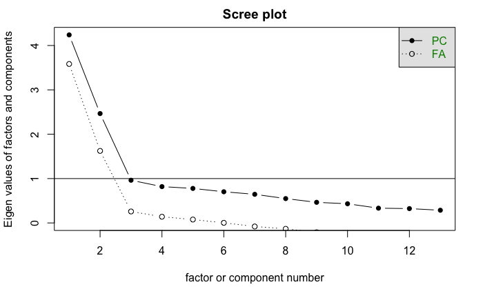

**Durchführung der explorativen Faktorenanalyse mit Promax-Rotation, da von einer Korrelation der beiden Faktoren untereinander ausgegangen werden muss**

```r
#| warning: false
#| message: false

feel_fa <- fa(df[c("feel_01",
                   "feel_02",
                   "feel_03",
                   "feel_04",
                   "feel_05",
                   "feel_06",
                   "feel_07",
                   "feel_08",
                   "feel_09",
                   "feel_10",
                   "feel_11",
                   "feel_12",
                   "feel_13")],
  nfactors = 2, rotate = "promax", use = "pairwise", scores = "regression")
```

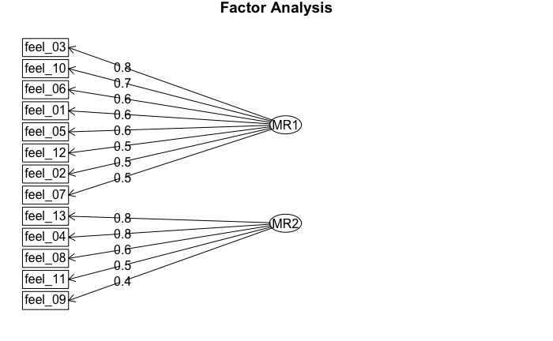

**Überprüfung der gefundenen Faktorenstruktur mit jeweils einer konfirmatorischen Faktorenanalyse pro Faktor**

### 3.1.1 Faktor 1 (ethnocultural)

```r
eth <- "ethno =~ feel_01 + feel_02 + feel_03 + feel_05 + feel_06 + feel_07 + feel_10 + feel_12"

eth_cfa <- cfa(model = eth, data = df, estimator = "MLR")

summary(eth_cfa, fit.measures = T, standardized = T, rsquar = T)
```

```
lavaan 0.6.14 ended normally after 25 iterations

  Estimator                                         ML
  Optimization method                           NLMINB
  Number of model parameters                        16

                                                  Used       Total
  Number of observations                           231         262

Model Test User Model:
                                              Standard      Scaled
  Test Statistic                                48.365      42.784
  Degrees of freedom                                20          20
  P-value (Chi-square)                           0.000       0.002
  Scaling correction factor                                  1.130
    Yuan-Bentler correction (Mplus variant)

Model Test Baseline Model:

  Test statistic                               551.608     478.591
  Degrees of freedom                                28          28
  P-value                                        0.000       0.000
  Scaling correction factor                                  1.153

User Model versus Baseline Model:

  Comparative Fit Index (CFI)                    0.946       0.949
  Tucker-Lewis Index (TLI)                       0.924       0.929

  Robust Comparative Fit Index (CFI)                         0.950
  Robust Tucker-Lewis Index (TLI)                            0.931

Loglikelihood and Information Criteria:

  Loglikelihood user model (H0)              -2558.897   -2558.897
  Scaling correction factor                                  1.123
      for the MLR correction
  Loglikelihood unrestricted model (H1)      -2534.715   -2534.715
  Scaling correction factor                                  1.127
      for the MLR correction
```

[output cut: 48 more lines]

```
   .feel_07           0.725    0.086    8.419    0.000    0.725    0.717
   .feel_10           0.580    0.077    7.547    0.000    0.580    0.400
   .feel_12           0.877    0.095    9.255    0.000    0.877    0.676
    ethno             0.381    0.114    3.336    0.001    1.000    1.000

R-Square:
                   Estimate
    feel_01           0.298
    feel_02           0.299
    feel_03           0.482
    feel_05           0.437
    feel_06           0.377
    feel_07           0.283
    feel_10           0.600
    feel_12           0.324
```

```r
semTools::reliability(eth_cfa, what = "alpha")
```

```
         ethno
alpha 0.829497
```

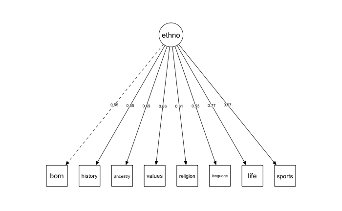

### 3.1.2 Faktor 2 (civic)

```r
civ <- "civic =~ feel_04 + feel_08 + feel_11 + feel_13"

civ_cfa <- cfa(model = civ, data = df, estimator = "MLR")

summary(civ_cfa, fit.measures = T, standardized = T, rsquar = T)
```

```
lavaan 0.6.14 ended normally after 23 iterations

  Estimator                                         ML
  Optimization method                           NLMINB
  Number of model parameters                         8

                                                  Used       Total
  Number of observations                           250         262

Model Test User Model:
                                              Standard      Scaled
  Test Statistic                                 3.006       2.152
  Degrees of freedom                                 2           2
  P-value (Chi-square)                           0.222       0.341
  Scaling correction factor                                  1.397
    Yuan-Bentler correction (Mplus variant)

Model Test Baseline Model:

  Test statistic                               279.644     170.698
  Degrees of freedom                                 6           6
  P-value                                        0.000       0.000
  Scaling correction factor                                  1.638

User Model versus Baseline Model:

  Comparative Fit Index (CFI)                    0.996       0.999
  Tucker-Lewis Index (TLI)                       0.989       0.997

  Robust Comparative Fit Index (CFI)                         0.999
  Robust Tucker-Lewis Index (TLI)                            0.998

Loglikelihood and Information Criteria:

  Loglikelihood user model (H0)              -1183.693   -1183.693
  Scaling correction factor                                  2.316
      for the MLR correction
  Loglikelihood unrestricted model (H1)      -1182.189   -1182.189
  Scaling correction factor                                  2.132
      for the MLR correction
```

[output cut: 36 more lines]

```

Variances:
                   Estimate  Std.Err  z-value  P(>|z|)   Std.lv  Std.all
   .feel_04           0.219    0.052    4.241    0.000    0.219    0.433
   .feel_08           0.514    0.090    5.706    0.000    0.514    0.627
   .feel_11           1.473    0.119   12.367    0.000    1.473    0.808
   .feel_13           0.144    0.053    2.706    0.007    0.144    0.237
    civic             0.287    0.081    3.520    0.000    1.000    1.000

R-Square:
                   Estimate
    feel_04           0.567
    feel_08           0.373
    feel_11           0.192
    feel_13           0.763
```

```r
semTools::reliability(civ_cfa, what = "alpha")
```

```
          civic
alpha 0.7001062
```

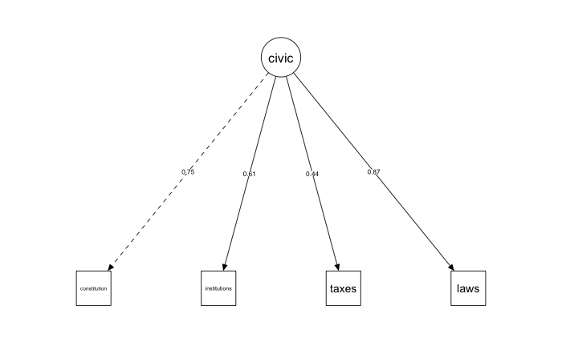

## 3.2 Patriotismus / Nationalismus

**Durchführung des Kaiser-Meyer-Olkin-Tests, um die Eignung der Variablen für eine Faktorenanalyse festzustellen**

```
Kaiser-Meyer-Olkin factor adequacy
Call: KMO(r = .)
Overall MSA =  0.67
MSA for each item =
patr_01 patr_02 patr_03 patr_04 patr_05 patr_06
   0.73    0.61    0.65    0.67    0.65    0.67
```

**Darstellung eines Screeplots, um die Anzahl der zu bestimmenden Faktoren zu erhalten**

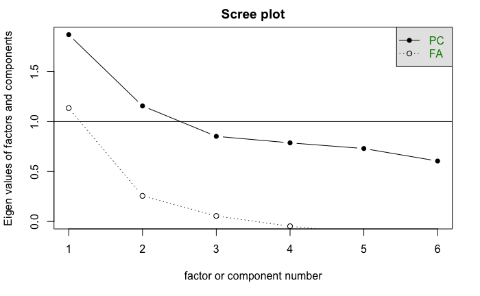

**Durchführung der explorativen Faktorenanalyse mit Promax-Rotation, da von einer Korrelation der Faktoren untereinander ausgegangen werden muss**

```r
patr_fa <- fa(df[c("patr_01",
                   "patr_02",
                   "patr_03",
                   "patr_04",
                   "patr_05",
                   "patr_06")],
   nfactors = 1, rotate = "promax", use = "pairwise", scores = "regression")
```

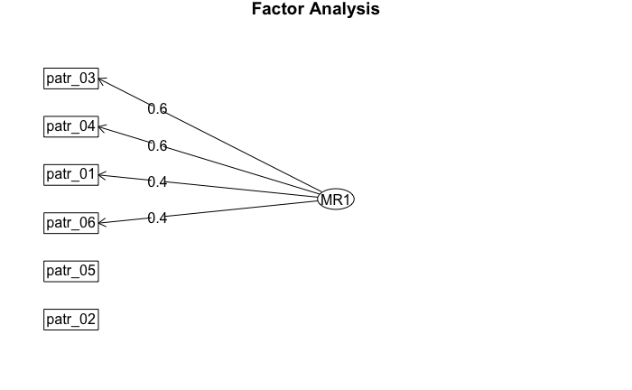

**Überprüfung der gefundenen Faktorenstruktur mit einer konfirmatorischen Faktorenanalyse**

```r
patr <- "patr =~ patr_01 + patr_03 + patr_04 + patr_06"

patr_cfa <- cfa(model = patr, data = df, estimator = "MLR")

summary(patr_cfa, fit.measures = T, standardized = T, rsquar = T)
```

```
lavaan 0.6.14 ended normally after 33 iterations

  Estimator                                         ML
  Optimization method                           NLMINB
  Number of model parameters                         8

                                                  Used       Total
  Number of observations                           243         262

Model Test User Model:
                                              Standard      Scaled
  Test Statistic                                 2.973       3.062
  Degrees of freedom                                 2           2
  P-value (Chi-square)                           0.226       0.216
  Scaling correction factor                                  0.971
    Yuan-Bentler correction (Mplus variant)

Model Test Baseline Model:

  Test statistic                                80.363      78.272
  Degrees of freedom                                 6           6
  P-value                                        0.000       0.000
  Scaling correction factor                                  1.027

User Model versus Baseline Model:

  Comparative Fit Index (CFI)                    0.987       0.985
  Tucker-Lewis Index (TLI)                       0.961       0.956

  Robust Comparative Fit Index (CFI)                         0.986
  Robust Tucker-Lewis Index (TLI)                            0.958

Loglikelihood and Information Criteria:

  Loglikelihood user model (H0)              -1461.541   -1461.541
  Scaling correction factor                                  0.883
      for the MLR correction
  Loglikelihood unrestricted model (H1)      -1460.054   -1460.054
  Scaling correction factor                                  0.900
      for the MLR correction
```

[output cut: 36 more lines]

```

Variances:
                   Estimate  Std.Err  z-value  P(>|z|)   Std.lv  Std.all
   .patr_01           1.070    0.104   10.328    0.000    1.070    0.842
   .patr_03           0.717    0.119    6.013    0.000    0.717    0.616
   .patr_04           0.659    0.121    5.463    0.000    0.659    0.631
   .patr_06           1.535    0.112   13.687    0.000    1.535    0.875
    patr              0.200    0.088    2.279    0.023    1.000    1.000

R-Square:
                   Estimate
    patr_01           0.158
    patr_03           0.384
    patr_04           0.369
    patr_06           0.125
```

```r
semTools::reliability(patr_cfa, what = "alpha")
```

```
           patr
alpha 0.5472704
```

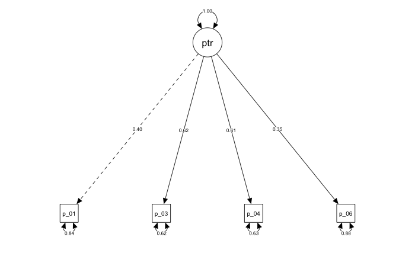

## 3.3 Autoritarismus / sozialliberale Werte

**Durchführung des Kaiser-Meyer-Olkin-Tests, um die Eignung der Variablen für eine Faktorenanalyse festzustellen**

```
Kaiser-Meyer-Olkin factor adequacy
Call: KMO(r = .)
Overall MSA =  0.83
MSA for each item =
ausoz_01 ausoz_02 ausoz_03 ausoz_04 ausoz_05 ausoz_06 ausoz_07 ausoz_08 ausoz_09 ausoz_10
    0.86     0.83     0.90     0.83     0.83     0.84     0.82     0.71     0.86     0.86
```

**Darstellung eines Screeplots, um die Anzahl der zu bestimmenden Faktoren zu erhalten**

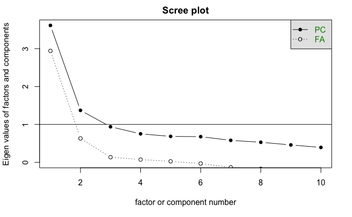

```r
ausoz_fa <- fa(df[c("ausoz_01",
                   "ausoz_02",
                   "ausoz_03",
                   "ausoz_04",
                   "ausoz_05",
                   "ausoz_06",
                   "ausoz_07",
                   "ausoz_08",
                   "ausoz_09",
                   "ausoz_10")],
  nfactors = 1, rotate = "promax", use = "pairwise", scores = "regression")
```

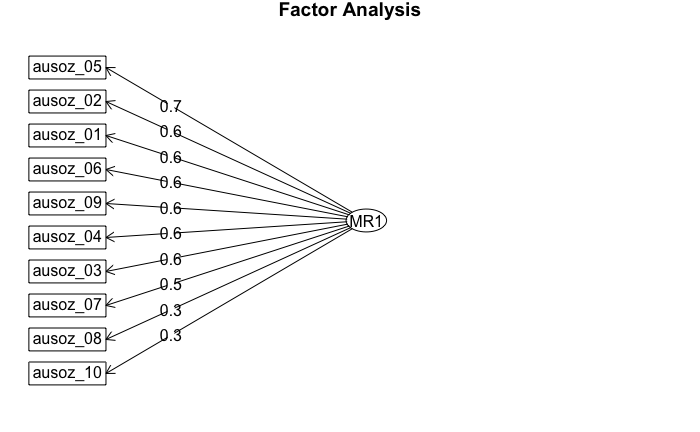

### 3.3.1 Faktor 1 (Autoritarismus)

```r
aut <- "aut =~ ausoz_01 + ausoz_02 + ausoz_03 + ausoz_04 + ausoz_05"

aut_cfa <- cfa(model = aut, data = df, estimator = "MLR")

summary(aut_cfa, fit.measures = T, standardized = T, rsquar = T)
```

```
lavaan 0.6.14 ended normally after 21 iterations

  Estimator                                         ML
  Optimization method                           NLMINB
  Number of model parameters                        10

                                                  Used       Total
  Number of observations                           230         262

Model Test User Model:
                                              Standard      Scaled
  Test Statistic                                 9.092       8.725
  Degrees of freedom                                 5           5
  P-value (Chi-square)                           0.105       0.121
  Scaling correction factor                                  1.042
    Yuan-Bentler correction (Mplus variant)

Model Test Baseline Model:

  Test statistic                               282.746     258.670
  Degrees of freedom                                10          10
  P-value                                        0.000       0.000
  Scaling correction factor                                  1.093

User Model versus Baseline Model:

  Comparative Fit Index (CFI)                    0.985       0.985
  Tucker-Lewis Index (TLI)                       0.970       0.970

  Robust Comparative Fit Index (CFI)                         0.986
  Robust Tucker-Lewis Index (TLI)                            0.971

Loglikelihood and Information Criteria:

  Loglikelihood user model (H0)              -1610.763   -1610.763
  Scaling correction factor                                  0.933
      for the MLR correction
  Loglikelihood unrestricted model (H1)      -1606.216   -1606.216
  Scaling correction factor                                  0.970
      for the MLR correction
```

[output cut: 39 more lines]

```
                   Estimate  Std.Err  z-value  P(>|z|)   Std.lv  Std.all
   .ausoz_01          0.701    0.080    8.736    0.000    0.701    0.587
   .ausoz_02          0.686    0.100    6.842    0.000    0.686    0.451
   .ausoz_03          0.771    0.076   10.185    0.000    0.771    0.729
   .ausoz_04          0.677    0.081    8.410    0.000    0.677    0.606
   .ausoz_05          0.695    0.088    7.928    0.000    0.695    0.545
    aut               0.493    0.102    4.857    0.000    1.000    1.000

R-Square:
                   Estimate
    ausoz_01          0.413
    ausoz_02          0.549
    ausoz_03          0.271
    ausoz_04          0.394
    ausoz_05          0.455
```

```r
semTools::reliability(aut_cfa, what = "alpha")
```

```
           aut
alpha 0.777909
```

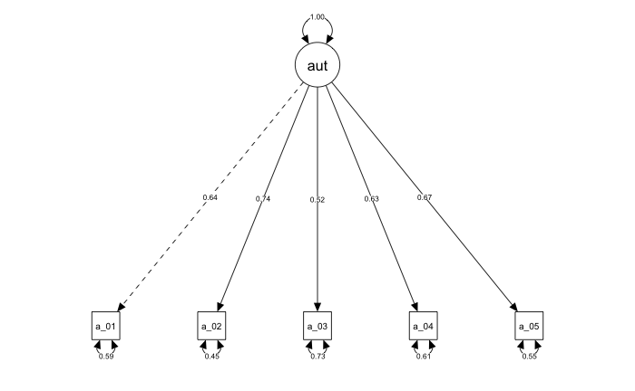

### 3.3.2 Faktor 2 (sozialliberale Werte)

```r
soz <- "soz =~ ausoz_06 + ausoz_07 + ausoz_08 + ausoz_09"

soz_cfa <- cfa(model = soz, data = df, estimator = "MLR")

summary(soz_cfa, fit.measures = T, standardized = T, rsquar = T)
```

```
lavaan 0.6.14 ended normally after 25 iterations

  Estimator                                         ML
  Optimization method                           NLMINB
  Number of model parameters                         8

                                                  Used       Total
  Number of observations                           247         262

Model Test User Model:
                                              Standard      Scaled
  Test Statistic                                 0.394       0.242
  Degrees of freedom                                 2           2
  P-value (Chi-square)                           0.821       0.886
  Scaling correction factor                                  1.625
    Yuan-Bentler correction (Mplus variant)

Model Test Baseline Model:

  Test statistic                               154.282      84.218
  Degrees of freedom                                 6           6
  P-value                                        0.000       0.000
  Scaling correction factor                                  1.832

User Model versus Baseline Model:

  Comparative Fit Index (CFI)                    1.000       1.000
  Tucker-Lewis Index (TLI)                       1.033       1.067

  Robust Comparative Fit Index (CFI)                         1.000
  Robust Tucker-Lewis Index (TLI)                            1.060

Loglikelihood and Information Criteria:

  Loglikelihood user model (H0)              -1260.774   -1260.774
  Scaling correction factor                                  2.375
      for the MLR correction
  Loglikelihood unrestricted model (H1)      -1260.577   -1260.577
  Scaling correction factor                                  2.225
      for the MLR correction
```

[output cut: 36 more lines]

```

Variances:
                   Estimate  Std.Err  z-value  P(>|z|)   Std.lv  Std.all
   .ausoz_06          0.763    0.105    7.249    0.000    0.763    0.817
   .ausoz_07          0.615    0.104    5.938    0.000    0.615    0.568
   .ausoz_08          0.431    0.105    4.113    0.000    0.431    0.655
   .ausoz_09          0.452    0.093    4.875    0.000    0.452    0.506
    soz               0.170    0.071    2.404    0.016    1.000    1.000

R-Square:
                   Estimate
    ausoz_06          0.183
    ausoz_07          0.432
    ausoz_08          0.345
    ausoz_09          0.494
```

```r
semTools::reliability(soz_cfa, what = "alpha")
```

```
            soz
alpha 0.6786891
```

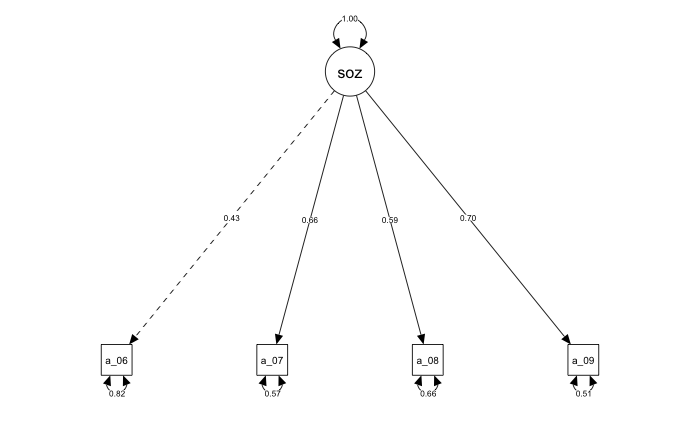

## 3.4 Xenophobie

**Durchführung des Kaiser-Meyer-Olkin-Tests, um die Eignung der Variablen für eine Faktorenanalyse festzustellen**

```
Kaiser-Meyer-Olkin factor adequacy
Call: KMO(r = .)
Overall MSA =  0.91
MSA for each item =
xeno_01 xeno_02 xeno_03 xeno_04 xeno_05 xeno_06 xeno_07
   0.94    0.95    0.87    0.86    0.91    0.94    0.91
```

**Darstellung eines Screeplots, um die Anzahl der zu bestimmenden Faktoren zu erhalten**

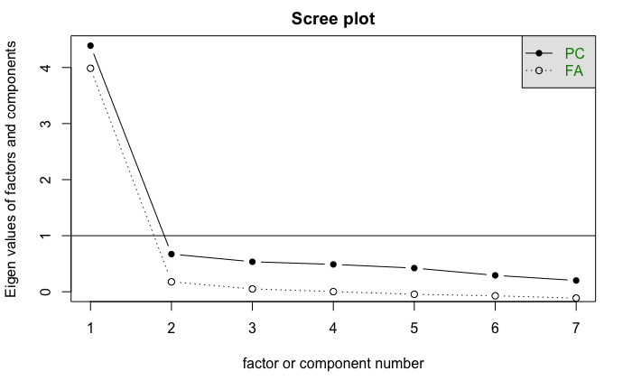

```r
xeno_fa <- fa(df[c("xeno_01",
                   "xeno_02",
                   "xeno_03",
                   "xeno_04",
                   "xeno_05",
                   "xeno_06",
                   "xeno_07")],
  nfactors = 1, rotate = "promax", use = "pairwise", scores = "regression")
```

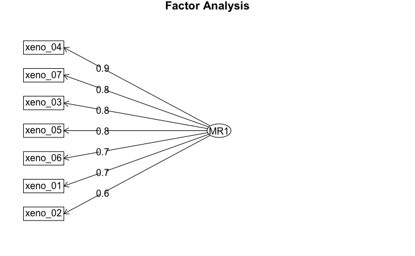

**Überprüfung der gefundenen Faktorenstruktur mit einer konfirmatorischen Faktorenanalyse**

```r
xeno <- "xeno =~ xeno_01 + xeno_02 + xeno_03 + xeno_04 + xeno_05 + xeno_06 + xeno_07"

xeno_cfa <- cfa(model = xeno, data = df, estimator = "MLR")

summary(xeno_cfa, fit.measures = T, standardized = T, rsquar = T)
```

```
lavaan 0.6.14 ended normally after 21 iterations

  Estimator                                         ML
  Optimization method                           NLMINB
  Number of model parameters                        14

                                                  Used       Total
  Number of observations                           236         262

Model Test User Model:
                                              Standard      Scaled
  Test Statistic                                41.241      32.980
  Degrees of freedom                                14          14
  P-value (Chi-square)                           0.000       0.003
  Scaling correction factor                                  1.250
    Yuan-Bentler correction (Mplus variant)

Model Test Baseline Model:

  Test statistic                               913.638     684.851
  Degrees of freedom                                21          21
  P-value                                        0.000       0.000
  Scaling correction factor                                  1.334

User Model versus Baseline Model:

  Comparative Fit Index (CFI)                    0.969       0.971
  Tucker-Lewis Index (TLI)                       0.954       0.957

  Robust Comparative Fit Index (CFI)                         0.973
  Robust Tucker-Lewis Index (TLI)                            0.960

Loglikelihood and Information Criteria:

  Loglikelihood user model (H0)              -2049.854   -2049.854
  Scaling correction factor                                  1.372
      for the MLR correction
  Loglikelihood unrestricted model (H1)      -2029.233   -2029.233
  Scaling correction factor                                  1.311
      for the MLR correction
```

[output cut: 45 more lines]

```
   .xeno_04           0.361    0.065    5.539    0.000    0.361    0.231
   .xeno_05           0.582    0.081    7.219    0.000    0.582    0.446
   .xeno_06           0.687    0.107    6.446    0.000    0.687    0.503
   .xeno_07           0.425    0.059    7.178    0.000    0.425    0.321
    xeno              0.519    0.093    5.610    0.000    1.000    1.000

R-Square:
                   Estimate
    xeno_01           0.425
    xeno_02           0.336
    xeno_03           0.675
    xeno_04           0.769
    xeno_05           0.554
    xeno_06           0.497
    xeno_07           0.679
```

```r
semTools::reliability(xeno_cfa, what = "alpha")
```

```
           xeno
alpha 0.8957541
```

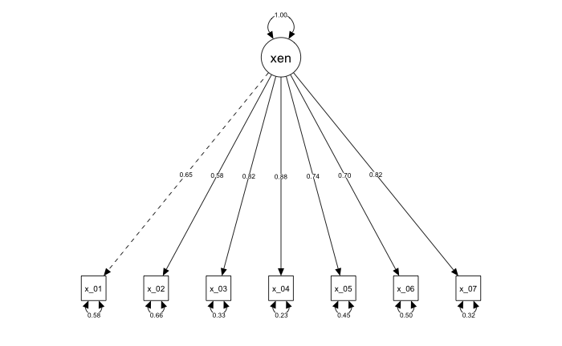

# 4 Datenaufbereitung

**Zusammenfassen der Variablen der identifizierten Faktoren mittels Mittelwertindizes**

## 4.1 ethnokulturelle Identität

```r
mean_eth <- df %>%
  select(feel_01, feel_02, feel_03, feel_05, feel_06, feel_07, feel_10, feel_12) %>%
  row_means(n=Inf)

mean_eth <- mean_eth %>%
  mutate(ethno = rec(rowmeans, rec =
                      "1:2=1 [nicht ethnokulturell];
                      2:3=2 [eher nicht ethnokulturell];
                      3:4=3 [eher ethnokulturell];
                      4:5=4 [ethnokulturell]"))

mean_eth <- mean_eth %>%
  select(ethno) %>%
  var_labels(ethno = "ethnokulturelle Identität")
```

```
ethnokulturelle Identität (x) <numeric>
# total N=262 valid N=231 mean=1.97 sd=0.82

Value |                     Label |   N | Raw % | Valid % | Cum. %
------------------------------------------------------------------
    1 |      nicht ethnokulturell |  72 | 27.48 |   31.17 |  31.17
    2 | eher nicht ethnokulturell | 105 | 40.08 |   45.45 |  76.62
    3 |       eher ethnokulturell |  44 | 16.79 |   19.05 |  95.67
    4 |            ethnokulturell |  10 |  3.82 |    4.33 | 100.00
 <NA> |                      <NA> |  31 | 11.83 |    <NA> |   <NA>
```

## 4.2 zivilpolitische Identität

```r
mean_civ <- df %>%
  select(feel_04, feel_08, feel_11, feel_13) %>%
  row_means(n=Inf)

mean_civ <- mean_civ %>%
  mutate(civ = rec(rowmeans, rec =
                      "1:2=1 [nicht zivilpolitisch];
                      2:3=2 [eher nicht zivilpolitisch];
                      3:4=3 [eher zivilpolitisch];
                      4:5=4 [zivilpolitisch]"))

mean_civ <- mean_civ %>%
  select(civ) %>%
  var_labels(civ = "zivilpolitische Identität")
```

```
zivilpolitische Identität (x) <numeric>
# total N=262 valid N=250 mean=3.64 sd=0.65

Value |                     Label |   N | Raw % | Valid % | Cum. %
------------------------------------------------------------------
    1 |      nicht zivilpolitisch |   6 |  2.29 |    2.40 |   2.40
    2 | eher nicht zivilpolitisch |   5 |  1.91 |    2.00 |   4.40
    3 |       eher zivilpolitisch |  62 | 23.66 |   24.80 |  29.20
    4 |            zivilpolitisch | 177 | 67.56 |   70.80 | 100.00
 <NA> |                      <NA> |  12 |  4.58 |    <NA> |   <NA>
```

## 4.3 Autoritarismus

```r
mean_aut <- df %>%
  select(ausoz_01, ausoz_02, ausoz_03, ausoz_04, ausoz_05) %>%
  row_means(n=Inf)

mean_aut <- mean_aut %>%
  mutate(aut = rec(rowmeans, rec =
                      "1:2=1 [nicht autoritär];
                      2:3=2 [eher nicht autoritär];
                      3:4=3 [eher autoritär];
                      4:5=4 [autoritär]"))

mean_aut <- mean_aut %>%
  select(aut) %>%
  var_labels(aut = "Autoritarismus")
```

```
Autoritarismus (x) <numeric>
# total N=262 valid N=230 mean=2.43 sd=0.82

Value |                Label |  N | Raw % | Valid % | Cum. %
------------------------------------------------------------
    1 |      nicht autoritär | 27 | 10.31 |   11.74 |  11.74
    2 | eher nicht autoritär | 99 | 37.79 |   43.04 |  54.78
    3 |       eher autoritär | 82 | 31.30 |   35.65 |  90.43
    4 |            autoritär | 22 |  8.40 |    9.57 | 100.00
 <NA> |                 <NA> | 32 | 12.21 |    <NA> |   <NA>
```

## 4.4 Xenophobie

```r
mean_xeno <- df %>%
  select(xeno_01, xeno_02, xeno_03, xeno_04, xeno_05, xeno_06, xeno_07) %>%
  row_means(n=Inf)

mean_xeno <- mean_xeno %>%
  mutate(xeno = rec(rowmeans, rec =
                      "1:2=1 [nicht xenophob];
                      2:3=2 [eher nicht xenophob];
                      3:4=3 [eher xenophob];
                      4:5=4 [xenophob]"))

mean_xeno <- mean_xeno %>%
  select(xeno) %>%
  var_labels(xeno = "Xenophobie")
```

```
Xenophobie (x) <numeric>
# total N=262 valid N=236 mean=1.73 sd=0.83

Value |               Label |   N | Raw % | Valid % | Cum. %
------------------------------------------------------------
    1 |      nicht xenophob | 114 | 43.51 |   48.31 |  48.31
    2 | eher nicht xenophob |  80 | 30.53 |   33.90 |  82.20
    3 |       eher xenophob |  34 | 12.98 |   14.41 |  96.61
    4 |            xenophob |   8 |  3.05 |    3.39 | 100.00
 <NA> |                <NA> |  26 |  9.92 |    <NA> |   <NA>
```

# 5 Analyse

## 5.1 t-Tests

**Durchführung von Zwei-Stichproben t-Tests, um festzustellen, ob es Unterschiede zwischen der “Frame-Gruppe” und der Kontrollgruppe gibt**

### 5.1.1 ethnokulturelle Identität

```
Levene's Test for Homogeneity of Variance (center = "mean")
       Df F value Pr(>F)
group   1  0.1938 0.6602
      229
```

```
    Two Sample t-test

data:  df$ethno by df$frame
t = -1.8342, df = 229, p-value = 0.06792
alternative hypothesis: true difference in means between group 0 and group 1 is not equal to 0
95 percent confidence interval:
 -0.4115537  0.0147283
sample estimates:
mean in group 0 mean in group 1
       1.857143        2.055556
```

### 5.1.2 zivilpolitische Identität

```
Levene's Test for Homogeneity of Variance (center = "mean")
       Df F value Pr(>F)
group   1    2.27 0.1332
      248
```

```
    Two Sample t-test

data:  df$civ by df$frame
t = -1.1022, df = 248, p-value = 0.2715
alternative hypothesis: true difference in means between group 0 and group 1 is not equal to 0
95 percent confidence interval:
 -0.25132325  0.07096898
sample estimates:
mean in group 0 mean in group 1
       3.591304        3.681481
```

### 5.1.3 erneute Überprüfung

**Entfernen aller Befragten, die weniger als 33 Sekunden mit dem Lesen des Frames verbracht haben**

```r
df <- df %>%
  mutate(frameread = case_when(
    TIME005 >= 33 & TIME005 < 380 ~ 1))

df$frameread <- ifelse(is.na(df$frameread), 0, df$frameread)
```

**ethnokulturelle Identität**

```
Levene's Test for Homogeneity of Variance (center = "mean")
       Df F value Pr(>F)
group   1  0.0202 0.8871
      229
```

```
    Two Sample t-test

data:  df$ethno by df$frameread
t = -0.83057, df = 229, p-value = 0.4071
alternative hypothesis: true difference in means between group 0 and group 1 is not equal to 0
95 percent confidence interval:
 -0.3124694  0.1271547
sample estimates:
mean in group 0 mean in group 1
       1.930070        2.022727
```

**zivilpolitische Identität**

```
Levene's Test for Homogeneity of Variance (center = "mean")
       Df F value Pr(>F)
group   1   1.028 0.3116
      248
```

```
    Two Sample t-test

data:  df$civ by df$frameread
t = -0.77669, df = 248, p-value = 0.4381
alternative hypothesis: true difference in means between group 0 and group 1 is not equal to 0
95 percent confidence interval:
 -0.2314798  0.1005469
sample estimates:
mean in group 0 mean in group 1
       3.615385        3.680851
```

## 5.2 lineare Regression

**Rekodieren der Bildungsvariable in drei Kategorien**

```r
df <- df %>%
  mutate(educ = rec(educ, rec =
                      "2:3=1 [niedrig];
                      4:6=2 [mittel];
                      7:8=3 [hoch];
                      1=NA")) %>%
  var_labels(educ = "Bildung")
```

**Dummy-Codierung der kategorialen Variablen**

```r
df <- df %>%
  to_label(educ, sex, wohngr)

df <- df %>%
  ref_lvl(educ, lvl = 2)

df <- df %>%
  ref_lvl(sex, lvl = 3)
```

**Entfernen aller Fälle, die fehlende Werte in mindestens einer der berücksichtigten Variablen haben**

```r
ds <- df %>%
  select(age,
         aut,
         xeno,
         dem,
         reli,
         depr,
         polint,
         lr,
         ethno,
         civ,
         educ,
         sex,
         wohngr) %>%
  drop_na()
```

**Alle metrischen Variablen müssen für die lineare Regressionsanalyse z-standardisiert werden**

```r
ds <- ds %>%
  mutate(ageZ = scale(age),
         autZ = scale(aut),
         xenoZ = scale(xeno),
         demZ = scale(dem),
         reliZ = scale(reli),
         deprZ = scale(depr),
         polintZ = scale(polint),
         lrZ = scale(lr))
```

### 5.2.1 ethnokulturelle Identität

```
Call:
lm(formula = ethno ~ xenoZ + autZ + demZ + sex + age + educ +
    lrZ + reliZ + wohngr + polintZ + deprZ, data = ds)

Residuals:
     Min       1Q   Median       3Q      Max
-1.37537 -0.40345 -0.01417  0.36242  2.29984

Coefficients:
                                                  Estimate Std. Error t value Pr(>|t|)
(Intercept)                                      2.3373334  0.5333702   4.382 2.33e-05 ***
xenoZ                                            0.1823557  0.0744853   2.448 0.015631 *
autZ                                             0.2315907  0.0653885   3.542 0.000545 ***
demZ                                            -0.0006766  0.0557365  -0.012 0.990332
sexweiblich                                     -0.2280033  0.4591815  -0.497 0.620313
sexmännlich                                     -0.2665503  0.4599992  -0.579 0.563239
age                                              0.0041632  0.0043082   0.966 0.335590
educniedrig                                     -0.0742849  0.5015512  -0.148 0.882475
educhoch                                        -0.1368383  0.2319619  -0.590 0.556225
lrZ                                              0.2681009  0.0704015   3.808 0.000211 ***
reliZ                                            0.0602726  0.0555494   1.085 0.279830
wohngrKleinstadt (bis 20.000 Einwohner)         -0.1850274  0.1865021  -0.992 0.322914
wohngrMittelgroße Stadt (bis 100.000 Einwohner) -0.0971253  0.1504258  -0.646 0.519581
wohngrGroßstadt (über 100.000 Einwohner)        -0.2924485  0.1662637  -1.759 0.080836 .
polintZ                                          0.0993517  0.0545844   1.820 0.070935 .
deprZ                                            0.1148894  0.0550205   2.088 0.038652 *
---
Signif. codes:  0 ‘***’ 0.001 ‘**’ 0.01 ‘*’ 0.05 ‘.’ 0.1 ‘ ’ 1

Residual standard error: 0.6202 on 136 degrees of freedom
Multiple R-squared:  0.5152,    Adjusted R-squared:  0.4617
F-statistic: 9.635 on 15 and 136 DF,  p-value: 3.762e-15
```

**regressionsdiagnostische Überprüfung des Modells**

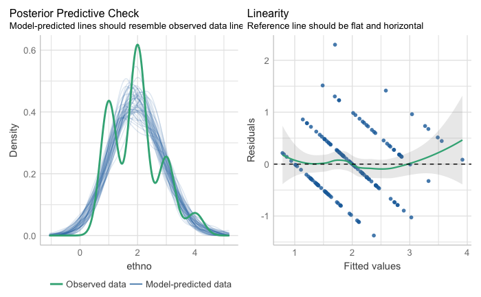

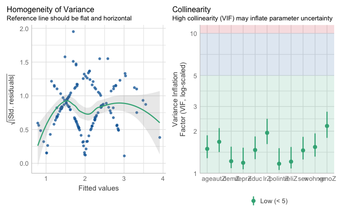

**zusätzliche Durchführung des Breusch-Pagan-Tests, um Homoskedastizität zu überprüfen**

```
    studentized Breusch-Pagan test

data:  eth_reg
BP = 11.136, df = 15, p-value = 0.7429
```

### 5.2.2 zivilpolitische Identität

```
Call:
lm(formula = civ ~ xenoZ + autZ + demZ + sex + age + educ + lrZ +
    reliZ + wohngr + polintZ + deprZ, data = ds)

Residuals:
    Min      1Q  Median      3Q     Max
-2.5904 -0.2715  0.1473  0.3820  0.9006

Coefficients:
                                                 Estimate Std. Error t value Pr(>|t|)
(Intercept)                                      3.112722   0.519030   5.997 1.71e-08 ***
xenoZ                                            0.019791   0.072483   0.273   0.7852
autZ                                             0.163155   0.063631   2.564   0.0114 *
demZ                                             0.086174   0.054238   1.589   0.1144
sexweiblich                                      0.261222   0.446836   0.585   0.5598
sexmännlich                                      0.079396   0.447632   0.177   0.8595
age                                              0.010148   0.004192   2.421   0.0168 *
educniedrig                                     -0.667703   0.488067  -1.368   0.1736
educhoch                                         0.029406   0.225725   0.130   0.8965
lrZ                                              0.037578   0.068509   0.549   0.5842
reliZ                                           -0.031463   0.054056  -0.582   0.5615
wohngrKleinstadt (bis 20.000 Einwohner)         -0.009712   0.181488  -0.054   0.9574
wohngrMittelgroße Stadt (bis 100.000 Einwohner) -0.001140   0.146382  -0.008   0.9938
wohngrGroßstadt (über 100.000 Einwohner)         0.035663   0.161794   0.220   0.8259
polintZ                                          0.016276   0.053117   0.306   0.7597
deprZ                                           -0.042199   0.053541  -0.788   0.4320
---
Signif. codes:  0 ‘***’ 0.001 ‘**’ 0.01 ‘*’ 0.05 ‘.’ 0.1 ‘ ’ 1

Residual standard error: 0.6035 on 136 degrees of freedom
Multiple R-squared:  0.1619,    Adjusted R-squared:  0.06943
F-statistic: 1.751 on 15 and 136 DF,  p-value: 0.04816
```

**regressionsdiagnostische Überprüfung des Modells**

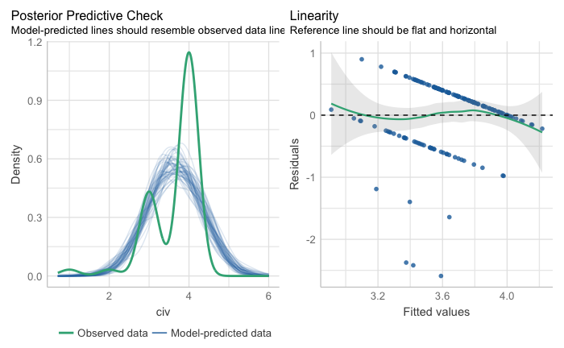

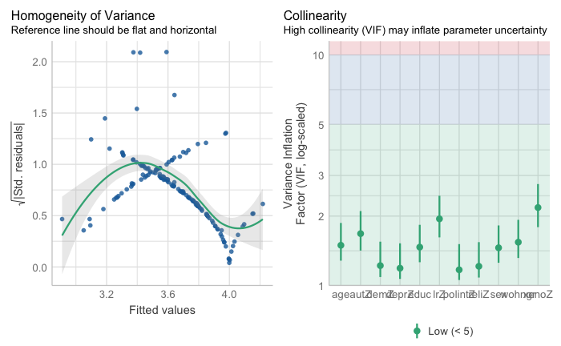

**zusätzliche Durchführung des Breusch-Pagan-Tests, um Homoskedastizität zu überprüfen**

```
    studentized Breusch-Pagan test

data:  civ_reg
BP = 13.784, df = 15, p-value = 0.542
```

# 6 Information